# python project 3

### 1. Import required libraries and read the provided dataset (youtube_dislike_dataset.csv) and retrieve top 5 and bottom 5 records.

```python
 import pandas as pd
import numpy as np
import matplotlib. pyplot as plot
df = pd.read_csv(r"C:\Users\satya\Downloads\youtube_dislike_dataset (1).csv")
```

```python
df.head(5)
```

|  | video_id | title | channel_id | channel_title | published_at | view_count | likes | dislikes | comment_count | tags | description | comments |
| --- | --- | --- | --- | --- | --- | --- | --- | --- | --- | --- | --- | --- |
| 0 | --0bCF-iK2E | Jadon Sancho Magical Skills & Goals | UC6UL29enLNe4mqwTfAyeNuw | Bundesliga | 2021-07-01 10:00:00 | 1048888 | 19515 | 226 | 1319 | football soccer ftbol alemn Bundesliga season ... | Enjoy the best skills and goals from Jadon San... | Respect to Dortmund fans,must be sad losing hi... |
| 1 | --14w5SOEUs | Migos - Avalanche (Official Video) | UCGIelM2Dj3zza3xyV3pL3WQ | MigosVEVO | 2021-06-10 16:00:00 | 15352638 | 359277 | 7479 | 18729 | Migos Avalanche Quality Control Music/Motown R... | Watch the the official video for Migos - "Aval... | Migos just makes me want to live my live to th... |
| 2 | --40TEbZ9Is | Supporting Actress in a Comedy: 73rd Emmys | UClBKH8yZRcM4AsRjDVEdjMg | Television Academy | 2021-09-20 01:03:32 | 925281 | 11212 | 401 | 831 |  | Hannah Waddingham wins the Emmy for Supporting... | Hannah's energy bursts through any screen. Wel... |
| 3 | --4tfbSyYDE | JO1'YOUNG (JO1 ver.)' PERFORMANCE VIDEO | UCsmXiDP8S40uBeJYxvyulmA | JO1 | 2021-03-03 10:00:17 | 2641597 | 39131 | 441 | 3745 | PRODUCE101JAPAN JO1 TheSTAR STA... | JO1'YOUNG (JO1 ver.)' PERFORMANCE VIDEO\n\n---... | youngVer>< REN is really PERFECT. It's not ju... |
| 4 | --DKkzWVh-E | Why Retaining Walls Collapse | UCMOqf8ab-42UUQIdVoKwjlQ | Practical Engineering | 2021-12-07 13:00:00 | 715724 | 32887 | 367 | 1067 | retaining wall New Jersey highway Direct Conne... | One of the most important (and innocuous) part... | Keep up with all my projects here: https://pr... |

```python
df.tail(5)
```

|  | video_id | title | channel_id | channel_title | published_at | view_count | likes | dislikes | comment_count | tags | description | comments |
| --- | --- | --- | --- | --- | --- | --- | --- | --- | --- | --- | --- | --- |
| 37417 | zzd4ydafGR0 | Lil Tjay - Calling My Phone (feat. 6LACK) [Off... | UCEB4a5o_6KfjxHwNMnmj54Q | Lil Tjay | 2021-02-12 05:03:49 | 120408275 | 2180780 | 35871 | 81360 | Lil Tjay Steady Calling My Phone Calling My Ph... | Official video for "Calling My Phone" by Lil T... | 'DESTINED 2 WIN' OUT NOW !! https://liltjay.ln... |
| 37418 | zziBybeSAtw | PELICANS at LAKERS \| FULL GAME HIGHLIGHTS \| Ja... | UCWJ2lWNubArHWmf3FIHbfcQ | NBA | 2021-01-16 05:39:05 | 2841917 | 20759 | 1049 | 2624 | NBA G League Basketball game-0022000187 Lakers... | PELICANS at LAKERS \| FULL GAME HIGHLIGHTS \| Ja... | Montrezl Harrell is going crazy with the rebou... |
| 37419 | zzk09ESX7e0 | [MV] (MAMAMOO) - Where Are We Now | UCuhAUMLzJxlP1W7mEk0_6lA | MAMAMOO | 2021-06-02 09:00:10 | 13346678 | 720854 | 4426 | 90616 | MAMAMOO WAW WAW MAMAMOO WAW Where Are We Now... | [MV] (MAMAMOO) - Where Are We Now\n\nInstagra... | I honestly do not know why this song hit so ha... |
| 37420 | zzmQEb0Em5I | FELLIPE ESCUDERO- Master Podcast #12 | UC8NjnNWMsRqq11NYvHAQb1g | Master Podcast | 2020-10-20 20:59:30 | 252057 | 19198 | 1234 | 1471 | master masterpodcast lord lord vinheteiro z z ... | DOCTOR HAIR\nhttps://www.thedoctorhair.com/?fb... | Foi um prazer passar esta tarde com vocs debat... |
| 37421 | zzxPZwaA-8w | Gareth Bale brace secures dramatic comeback on... | UCEg25rdRZXg32iwai6N6l0w | Tottenham Hotspur | 2021-05-23 21:00:31 | 2252090 | 34063 | 868 | 2004 | Spurs Tottenham Hotspur Tottenham Leicester ... | Two minute highlights from Tottenham Hotspur's... | Thank you Kane for everything you have given t... |

### 2. Check the info of the dataframe and write your inferences on data types and shape of the dataset.

```python
df.info()
```

```
<class 'pandas.core.frame.DataFrame'>
RangeIndex: 37422 entries, 0 to 37421
Data columns (total 12 columns):
 #   Column         Non-Null Count  Dtype
---  ------         --------------  -----
 0   video_id       37422 non-null  object
 1   title          37422 non-null  object
 2   channel_id     37422 non-null  object
 3   channel_title  37422 non-null  object
 4   published_at   37422 non-null  object
 5   view_count     37422 non-null  int64
 6   likes          37422 non-null  int64
 7   dislikes       37422 non-null  int64
 8   comment_count  37422 non-null  int64
 9   tags           37422 non-null  object
 10  description    37422 non-null  object
 11  comments       37264 non-null  object
dtypes: int64(4), object(8)
memory usage: 3.4+ MB
```

```python
type(df)
```

```
pandas.core.frame.DataFrame
```

```python
df.shape
```

```
(37422, 12)
```

In the above output a summary of the dataframe's information, including the data types and non-null counts for each column. From this information, we can make inferences about the dataset's structure. The following dataframe consists of 37422 rows, 12 columns .Each rows represented the data about the video published .

### 3. Check for the Percentage of the missing values and drop or impute them.

```python
missing_values = df.isnull().sum()
```

```python
missing_values
```

```
video_id           0
title              0
channel_id         0
channel_title      0
published_at       0
view_count         0
likes              0
dislikes           0
comment_count      0
tags               0
description        0
comments         158
dtype: int64
```

```python
df.isnull().sum()/(len(df)*100)
```

```
video_id         0.000000
title            0.000000
channel_id       0.000000
channel_title    0.000000
published_at     0.000000
view_count       0.000000
likes            0.000000
dislikes         0.000000
comment_count    0.000000
tags             0.000000
description      0.000000
comments         0.000042
dtype: float64
```

```python
df.drop(columns="comments",inplace = True)
```

```python
df.isnull().sum()
```

```
video_id         0
title            0
channel_id       0
channel_title    0
published_at     0
view_count       0
likes            0
dislikes         0
comment_count    0
tags             0
description      0
dtype: int64
```

### 4. Check the statistical summary of both numerical and categorical columns and write your inferences

```python
numerical_summary = df.describe()
```

```python
categorical_summary = {}
for column in df.select_dtypes(include=['object']):
    categorical_summary[column] = df[column].value_counts()
```

```python
print("Statistical Summary for Numerical Columns:")
display(numerical_summary)
```

```
Statistical Summary for Numerical Columns:
```

|  | view_count | likes | dislikes | comment_count |
| --- | --- | --- | --- | --- |
| count | 3.742200e+04 | 3.742200e+04 | 3.742200e+04 | 3.742200e+04 |
| mean | 5.697838e+06 | 1.668147e+05 | 4.989862e+03 | 9.924930e+03 |
| std | 2.426622e+07 | 5.375670e+05 | 3.070824e+04 | 1.171003e+05 |
| min | 2.036800e+04 | 0.000000e+00 | 0.000000e+00 | 0.000000e+00 |
| 25% | 5.122970e+05 | 1.323350e+04 | 2.810000e+02 | 9.000000e+02 |
| 50% | 1.319078e+06 | 4.233050e+04 | 7.960000e+02 | 2.328000e+03 |
| 75% | 3.670231e+06 | 1.304698e+05 | 2.461750e+03 | 6.184000e+03 |
| max | 1.322797e+09 | 3.183768e+07 | 2.397733e+06 | 1.607103e+07 |

The Numerical columns consist of view_counts, likes,dislikes,comment-counts. the statical summary for the numerical datatypes provided with us the discriptive details abouts our dataset.

### 5. Convert datatype of column published_at from object to pandas datetime.

```python
df['published_at'] = pd.to_datetime(df['published_at'])
```

```python
df.dtypes
```

```
video_id                 object
title                    object
channel_id               object
channel_title            object
published_at     datetime64[ns]
view_count                int64
likes                     int64
dislikes                  int64
comment_count             int64
tags                     object
description              object
dtype: object
```

### 6. Create a new column as 'published_month' using the column published_at (display the months only)

```python
df["published_month"]=df["published_at"].dt.month
```

```python
df
```

|  | video_id | title | channel_id | channel_title | published_at | view_count | likes | dislikes | comment_count | tags | description | published_month |
| --- | --- | --- | --- | --- | --- | --- | --- | --- | --- | --- | --- | --- |
| 0 | --0bCF-iK2E | Jadon Sancho Magical Skills & Goals | UC6UL29enLNe4mqwTfAyeNuw | Bundesliga | 2021-07-01 10:00:00 | 1048888 | 19515 | 226 | 1319 | football soccer ftbol alemn Bundesliga season ... | Enjoy the best skills and goals from Jadon San... | 7 |
| 1 | --14w5SOEUs | Migos - Avalanche (Official Video) | UCGIelM2Dj3zza3xyV3pL3WQ | MigosVEVO | 2021-06-10 16:00:00 | 15352638 | 359277 | 7479 | 18729 | Migos Avalanche Quality Control Music/Motown R... | Watch the the official video for Migos - "Aval... | 6 |
| 2 | --40TEbZ9Is | Supporting Actress in a Comedy: 73rd Emmys | UClBKH8yZRcM4AsRjDVEdjMg | Television Academy | 2021-09-20 01:03:32 | 925281 | 11212 | 401 | 831 |  | Hannah Waddingham wins the Emmy for Supporting... | 9 |
| 3 | --4tfbSyYDE | JO1'YOUNG (JO1 ver.)' PERFORMANCE VIDEO | UCsmXiDP8S40uBeJYxvyulmA | JO1 | 2021-03-03 10:00:17 | 2641597 | 39131 | 441 | 3745 | PRODUCE101JAPAN JO1 TheSTAR STA... | JO1'YOUNG (JO1 ver.)' PERFORMANCE VIDEO\n\n---... | 3 |
| 4 | --DKkzWVh-E | Why Retaining Walls Collapse | UCMOqf8ab-42UUQIdVoKwjlQ | Practical Engineering | 2021-12-07 13:00:00 | 715724 | 32887 | 367 | 1067 | retaining wall New Jersey highway Direct Conne... | One of the most important (and innocuous) part... | 12 |
| ... | ... | ... | ... | ... | ... | ... | ... | ... | ... | ... | ... | ... |
| 37417 | zzd4ydafGR0 | Lil Tjay - Calling My Phone (feat. 6LACK) [Off... | UCEB4a5o_6KfjxHwNMnmj54Q | Lil Tjay | 2021-02-12 05:03:49 | 120408275 | 2180780 | 35871 | 81360 | Lil Tjay Steady Calling My Phone Calling My Ph... | Official video for "Calling My Phone" by Lil T... | 2 |
| 37418 | zziBybeSAtw | PELICANS at LAKERS \| FULL GAME HIGHLIGHTS \| Ja... | UCWJ2lWNubArHWmf3FIHbfcQ | NBA | 2021-01-16 05:39:05 | 2841917 | 20759 | 1049 | 2624 | NBA G League Basketball game-0022000187 Lakers... | PELICANS at LAKERS \| FULL GAME HIGHLIGHTS \| Ja... | 1 |
| 37419 | zzk09ESX7e0 | [MV] (MAMAMOO) - Where Are We Now | UCuhAUMLzJxlP1W7mEk0_6lA | MAMAMOO | 2021-06-02 09:00:10 | 13346678 | 720854 | 4426 | 90616 | MAMAMOO WAW WAW MAMAMOO WAW Where Are We Now... | [MV] (MAMAMOO) - Where Are We Now\n\nInstagra... | 6 |
| 37420 | zzmQEb0Em5I | FELLIPE ESCUDERO- Master Podcast #12 | UC8NjnNWMsRqq11NYvHAQb1g | Master Podcast | 2020-10-20 20:59:30 | 252057 | 19198 | 1234 | 1471 | master masterpodcast lord lord vinheteiro z z ... | DOCTOR HAIR\nhttps://www.thedoctorhair.com/?fb... | 10 |
| 37421 | zzxPZwaA-8w | Gareth Bale brace secures dramatic comeback on... | UCEg25rdRZXg32iwai6N6l0w | Tottenham Hotspur | 2021-05-23 21:00:31 | 2252090 | 34063 | 868 | 2004 | Spurs Tottenham Hotspur Tottenham Leicester ... | Two minute highlights from Tottenham Hotspur's... | 5 |

37422 rows × 12 columns

### 7. Replace the numbers in the column published_month as names of the months i,e., 1 as 'Jan', 2 as 'Feb' and so on....

```python
month_name = { 1:'Jan',2:'Feb',3:'Mar',4:'Apr',5:'May',6:'Jun',
              7:'Jul',8:'Aug',9:'Sep',10:'Oct',11:'Nov',12:'Dec'}
```

```python
df['published_month']= df['published_month'].map(month_name)
```

```python
df
```

|  | video_id | title | channel_id | channel_title | published_at | view_count | likes | dislikes | comment_count | tags | description | published_month |
| --- | --- | --- | --- | --- | --- | --- | --- | --- | --- | --- | --- | --- |
| 0 | --0bCF-iK2E | Jadon Sancho Magical Skills & Goals | UC6UL29enLNe4mqwTfAyeNuw | Bundesliga | 2021-07-01 10:00:00 | 1048888 | 19515 | 226 | 1319 | football soccer ftbol alemn Bundesliga season ... | Enjoy the best skills and goals from Jadon San... | Jul |
| 1 | --14w5SOEUs | Migos - Avalanche (Official Video) | UCGIelM2Dj3zza3xyV3pL3WQ | MigosVEVO | 2021-06-10 16:00:00 | 15352638 | 359277 | 7479 | 18729 | Migos Avalanche Quality Control Music/Motown R... | Watch the the official video for Migos - "Aval... | Jun |
| 2 | --40TEbZ9Is | Supporting Actress in a Comedy: 73rd Emmys | UClBKH8yZRcM4AsRjDVEdjMg | Television Academy | 2021-09-20 01:03:32 | 925281 | 11212 | 401 | 831 |  | Hannah Waddingham wins the Emmy for Supporting... | Sep |
| 3 | --4tfbSyYDE | JO1'YOUNG (JO1 ver.)' PERFORMANCE VIDEO | UCsmXiDP8S40uBeJYxvyulmA | JO1 | 2021-03-03 10:00:17 | 2641597 | 39131 | 441 | 3745 | PRODUCE101JAPAN JO1 TheSTAR STA... | JO1'YOUNG (JO1 ver.)' PERFORMANCE VIDEO\n\n---... | Mar |
| 4 | --DKkzWVh-E | Why Retaining Walls Collapse | UCMOqf8ab-42UUQIdVoKwjlQ | Practical Engineering | 2021-12-07 13:00:00 | 715724 | 32887 | 367 | 1067 | retaining wall New Jersey highway Direct Conne... | One of the most important (and innocuous) part... | Dec |
| ... | ... | ... | ... | ... | ... | ... | ... | ... | ... | ... | ... | ... |
| 37417 | zzd4ydafGR0 | Lil Tjay - Calling My Phone (feat. 6LACK) [Off... | UCEB4a5o_6KfjxHwNMnmj54Q | Lil Tjay | 2021-02-12 05:03:49 | 120408275 | 2180780 | 35871 | 81360 | Lil Tjay Steady Calling My Phone Calling My Ph... | Official video for "Calling My Phone" by Lil T... | Feb |
| 37418 | zziBybeSAtw | PELICANS at LAKERS \| FULL GAME HIGHLIGHTS \| Ja... | UCWJ2lWNubArHWmf3FIHbfcQ | NBA | 2021-01-16 05:39:05 | 2841917 | 20759 | 1049 | 2624 | NBA G League Basketball game-0022000187 Lakers... | PELICANS at LAKERS \| FULL GAME HIGHLIGHTS \| Ja... | Jan |
| 37419 | zzk09ESX7e0 | [MV] (MAMAMOO) - Where Are We Now | UCuhAUMLzJxlP1W7mEk0_6lA | MAMAMOO | 2021-06-02 09:00:10 | 13346678 | 720854 | 4426 | 90616 | MAMAMOO WAW WAW MAMAMOO WAW Where Are We Now... | [MV] (MAMAMOO) - Where Are We Now\n\nInstagra... | Jun |
| 37420 | zzmQEb0Em5I | FELLIPE ESCUDERO- Master Podcast #12 | UC8NjnNWMsRqq11NYvHAQb1g | Master Podcast | 2020-10-20 20:59:30 | 252057 | 19198 | 1234 | 1471 | master masterpodcast lord lord vinheteiro z z ... | DOCTOR HAIR\nhttps://www.thedoctorhair.com/?fb... | Oct |
| 37421 | zzxPZwaA-8w | Gareth Bale brace secures dramatic comeback on... | UCEg25rdRZXg32iwai6N6l0w | Tottenham Hotspur | 2021-05-23 21:00:31 | 2252090 | 34063 | 868 | 2004 | Spurs Tottenham Hotspur Tottenham Leicester ... | Two minute highlights from Tottenham Hotspur's... | May |

37422 rows × 12 columns

### 8. Find the number of videos published each month and arrange the months in a decreasing order base

```python
videos_count = df.groupby('published_month')['video_id'].count().sort_values(ascending=False)

print(videos_count)
```

```
published_month
Oct    4991
Sep    4880
Nov    4851
Aug    4262
Dec    3072
Jul    2340
Jun    2316
Mar    2258
Feb    2137
Apr    2126
Jan    2108
May    2081
Name: video_id, dtype: int64
```

### 9. Find the count of unique video_id, channel_id and channel_title

```python
unique_video_id_count = df['video_id'].nunique()
unique_channel_id_count = df['channel_id'].nunique()
# Count of unique channel_title
unique_channel_title_count = df['channel_title'].nunique()
# Display the counts
print("Count of unique video_id:", unique_video_id_count)
print("Count of unique channel_id:", unique_channel_id_count)
print("Count of unique channel_title:", unique_channel_title_count)
```

```
Count of unique video_id: 37422
Count of unique channel_id: 10961
Count of unique channel_title: 10883
```

### 10. Find the top10 channel names having the highest number of videos in the dataset and the bottom10 having lowest number of videos.

```python
channel_video_counts = df.groupby('channel_title')['video_id'].count().reset_index()
```

```python
channel_video_counts = channel_video_counts.sort_values(by='video_id', ascending=False)
```

```python
top_10_channels = channel_video_counts.head(10)
```

```python
bottom_10_channels = channel_video_counts.tail(10)
```

```python
print("Top 10 channels with the highest number of videos:")
print(top_10_channels)
```

```
Top 10 channels with the highest number of videos:
            channel_title  video_id
8276  Sky Sports Football       533
9160     The United Stand       301
1089             BT Sport       246
6355                  NBA       209
6394                  NFL       162
9845                  WWE       122
7862         SSSniperWolf        99
7863              SSundee        98
3058            FORMULA 1        87
6399                  NHL        86
```

```python
print("\nBottom 10 channels with the lowest number of videos:")
print(bottom_10_channels)
```

```
Bottom 10 channels with the lowest number of videos:
        channel_title  video_id
4816          Karchez         1
4815    Karate Combat         1
4813     Kaptain Kuba         1
4808       Kanye West         1
4807   Kannur kitchen         1
4806   Kannada Cinema         1
4802           KanalD         1
4800       Kanak News         1
4798    Kamille Ramos         1
10882            zoom         1
```

### 11. Find the title of the video which has the maximum number of likes and the title of the video having minimum likes and write your inferences

```python
max_likes_video = df[df['likes'] == df['likes'].max()]['title'].values[0]
min_likes_video = df[df['likes'] == df['likes'].min()]['title'].values[0]
print("Video with maximum likes:", max_likes_video)
print("Video with minimum likes:", min_likes_video)
```

```
Video with maximum likes: BTS () 'Dynamite' Official MV
Video with minimum likes: Kim Kardashian's Must-See Moments on "Saturday Night Live" | E! News
```

The maximum liked videos are "BTS () 'Dynamite' Official MV" & the minimum liked videos are "Kim Kardashian's Must-See Moments on "Saturday Night Live" | E! News".

### 12. Find the title of the video which has the maximum number of dislikes and the title of the video having minimum dislikes and write your inferences

```python
max_dislikes_video = df.loc[df['dislikes'].idxmax()]

min_dislikes_video = df.loc[df['dislikes'].idxmin()]
```

```python
print("Video with maximum dislikes:")
print(max_dislikes_video['title'])
print("Number of dislikes:", max_dislikes_video['dislikes'])
```

```
Video with maximum dislikes:
Cuties | Official Trailer | Netflix
Number of dislikes: 2397733
```

```python
print("\nVideo with minimum dislikes:")
print(min_dislikes_video['title'])
print("Number of dislikes:", min_dislikes_video['dislikes'])
```

```
Video with minimum dislikes:
Kim Kardashian's Must-See Moments on "Saturday Night Live" | E! News
Number of dislikes: 0
```

The maximum disliked videos are "Cuties | Official Trailer | Netflix" & the minimum disliked videos are "Kim Kardashian's Must-See Moments on "Saturday Night Live" | E! News".

### 13. Does the number of views have any effect on how many people disliked the video? Support your answer with a metric and a plot

```python
corr = df ["view_count"].corr(df["dislikes"])
```

```python
corr
```

```
0.6844687753905536
```

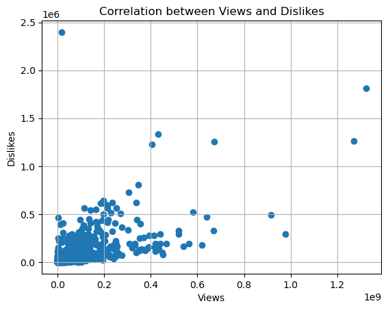

```python
plot.scatter(df["view_count"],df["dislikes"])
plot.xlabel("Views")
plot.ylabel("Dislikes")
plot.title("Correlation between Views and Dislikes")
plot.grid(True)
plot.show()
```

The correlation between views and dislikes is 0.684.It means it's is having derived the relation and increased in one leads to incresing another.

### 14. Display all the information about the videos that were published in January, and mention the count of videos that were published in January

```python
january_videos = df[df['published_month']=='Jan']
```

```python
january_videos.describe()
```

|  | published_at | view_count | likes | dislikes | comment_count |
| --- | --- | --- | --- | --- | --- |
| count | 2108 | 2.108000e+03 | 2.108000e+03 | 2108.000000 | 2.108000e+03 |
| mean | 2021-01-17 11:32:44.133301504 | 4.976449e+06 | 1.315030e+05 | 3614.568311 | 8.923385e+03 |
| min | 2021-01-01 00:00:54 | 2.845000e+04 | 2.800000e+01 | 3.000000 | 0.000000e+00 |
| 25% | 2021-01-09 22:42:18.750000128 | 4.322335e+05 | 1.032400e+04 | 249.000000 | 8.747500e+02 |
| 50% | 2021-01-17 18:35:30 | 1.147500e+06 | 3.173900e+04 | 729.000000 | 2.328500e+03 |
| 75% | 2021-01-25 14:00:07.750000128 | 3.227483e+06 | 1.076512e+05 | 2243.250000 | 6.302000e+03 |
| max | 2021-01-31 23:15:09 | 6.203274e+08 | 7.828036e+06 | 409144.000000 | 1.095119e+06 |
| std | NaN | 2.055331e+07 | 3.886887e+05 | 13946.711333 | 3.664662e+04 |

```python
january_videos.count= len(january_videos)
```

```python
january_videos.count
```

```
2108
```